# Practical Machine Learning - Prediction Assignment Writeup

Jayant Ragde

October 15, 2016

# Introduction

One thing that people regularly do is quantify how much of a particular activity they do, but they rarely quantify how well they do it. Using devices such as Jawbone Up, Nike FuelBand, and Fitbit it is now possible to collect a large amount of data about personal activity relatively inexpensively. This project looks at various recorded parameters of 6 participants performing a dumbell activity in 5 ways - 1 correct and 4 incorrect. A model will be built to predict correctness based on most relevant measured parameters.

Data and information for this report has been used from the following paper. Permission to use the data and analysis is appreciated.

Velloso, E.; Bulling, A.; Gellersen, H.; Ugulino, W.; Fuks, H. Qualitative Activity Recognition of Weight Lifting Exercises. Proceedings of 4th International Conference in Cooperation with SIGCHI (Augmented Human ’13) . Stuttgart, Germany: ACM SIGCHI, 2013.

# Data set up

## Environment set up

Disable warning messages when loading libraries.

The following libraries are used.

```r
library(caret)
```

```r
library(rpart)
library(rpart.plot)
library(randomForest)
library(corrplot)
```

## Download Data

Data for this project is downloaded from

Training Data: https://d396qusza40orc.cloudfront.net/predmachlearn/pml-training.csv

Test Data: https://d396qusza40orc.cloudfront.net/predmachlearn/pml-testing.csv

```r
trainingUrl <-"https://d396qusza40orc.cloudfront.net/predmachlearn/pml-training.csv"
testingUrl <- "https://d396qusza40orc.cloudfront.net/predmachlearn/pml-testing.csv"

if (!file.exists("./data")) {
  dir.create("./data")
}
if (!file.exists("./data/pml-training.csv")) {
  download.file(trainingUrl, destfile="./data/pml-training.csv", quiet = TRUE)
}
if (!file.exists("./data/pml-testing.csv")) {
  download.file(testingUrl, destfile=",/data/pml-testing.csv", quiet = TRUE)
}

# A quick look at the CSV files shows that there are many entries which are either
# blank or have #DIV/0!.  Replace all these with NA when reading the file.
#

trngData <- read.csv("./data/pml-training.csv", na.strings=c("NA","#DIV/0!",""))
tstData  <- read.csv("./data/pml-testing.csv", na.strings=c("NA","#DIV/0!",""))
```

## Data Cleaning

Identify and remove columns that have “NA”. Rows 1-7 have data not pertinent to this analysis. These will be removed.

```r
# Get list of column names with NA values
nonNARows <- names(tstData[,colSums(is.na(tstData))==0])
# remove first and last columns (Row number and problem_id)
nonNARows <- nonNARows[-c(1,60)]

# Now remove those columns from training and test data
clnTrnData <- trngData[,c(nonNARows, "classe")]
clnTstData <- tstData[,c(nonNARows, "problem_id")]

# Rmove rows 1 - 7
clnTrnData <- clnTrnData[,-c(1:7)]
clnTstData <- clnTstData[,-c(1:7)]
```

## Partition data

Partition the training data using 70% for training and 30% for validation

```r
set.seed(38597)
inTrain <- createDataPartition(clnTrnData$classe, p=0.7, list = FALSE)
training <- clnTrnData[inTrain,]
testing <- clnTrnData[-inTrain,]
```

## Random Forest Method

Use Random Forest method to build a model.

```r
# Create model
modFitRF <- randomForest(classe ~ ., training)
# Print model details
print(modFitRF, digits=3)
```

```
##
## Call:
##  randomForest(formula = classe ~ ., data = training)
##                Type of random forest: classification
##                      Number of trees: 500
## No. of variables tried at each split: 7
##
##         OOB estimate of  error rate: 0.58%
## Confusion matrix:
##      A    B    C    D    E  class.error
## A 3903    2    0    0    1 0.0007680492
## B   10 2643    5    0    0 0.0056433409
## C    0   17 2376    3    0 0.0083472454
## D    0    0   30 2220    2 0.0142095915
## E    0    0    3    7 2515 0.0039603960
```

Viewing the peformance of the model in the following plot it can be observed that error drops off dramatically to near zero.

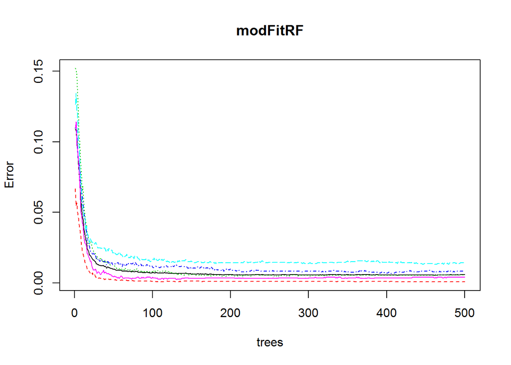

```r
# Plot Model
plot(modFitRF)
```

Then use the partitioned data to validate the model.

```r
# Predict using partitioned data
predRF <- predict(modFitRF, testing, type = "class")
# Create confusion matrix and display
cmRF <- confusionMatrix(predRF, testing$classe)
cmRF
```

```
## Confusion Matrix and Statistics
##
##           Reference
## Prediction    A    B    C    D    E
##          A 1671    6    0    0    0
##          B    2 1132   10    0    0
##          C    0    1 1016   10    1
##          D    1    0    0  954    1
##          E    0    0    0    0 1080
##
## Overall Statistics
##
##                Accuracy : 0.9946
##                  95% CI : (0.9923, 0.9963)
##     No Information Rate : 0.2845
##     P-Value [Acc > NIR] : < 2.2e-16
##
##                   Kappa : 0.9931
##  Mcnemar's Test P-Value : NA
##
## Statistics by Class:
##
##                      Class: A Class: B Class: C Class: D Class: E
## Sensitivity            0.9982   0.9939   0.9903   0.9896   0.9982
## Specificity            0.9986   0.9975   0.9975   0.9996   1.0000
## Pos Pred Value         0.9964   0.9895   0.9883   0.9979   1.0000
## Neg Pred Value         0.9993   0.9985   0.9979   0.9980   0.9996
## Prevalence             0.2845   0.1935   0.1743   0.1638   0.1839
## Detection Rate         0.2839   0.1924   0.1726   0.1621   0.1835
## Detection Prevalence   0.2850   0.1944   0.1747   0.1624   0.1835
## Balanced Accuracy      0.9984   0.9957   0.9939   0.9946   0.9991
```

Calculate and display the accuracy of the prediction.

```r
# calculate and display accuracy of prediction
cmRF$overall
```

```
##       Accuracy          Kappa  AccuracyLower  AccuracyUpper   AccuracyNull
##      0.9945624      0.9931215      0.9923324      0.9962778      0.2844520
## AccuracyPValue  McnemarPValue
##      0.0000000            NaN
```

The random forest technique removes closely correlated variables by selecting the appropriate split between trees. This reduces the out of sample error values and increases the accuracy. As observed, with an accuracy of 99.46% and an out of sample error of 0.54%. Hence this model can predict the correctness of the exercise based on the data with a high level of accuracy.

## Testing Set Prediction

Using the testing data set (20 observations), the predicted values of ‘classe’ or the correctness of performing the exercise is shown below.

```r
# Predict using test data
predTestRF <- predict(modFitRF, clnTstData, type = "class")
predTestRF
```

```
##  1  2  3  4  5  6  7  8  9 10 11 12 13 14 15 16 17 18 19 20
##  B  A  B  A  A  E  D  B  A  A  B  C  B  A  E  E  A  B  B  B
## Levels: A B C D E
```